# 04_DID checks

Andrea Molino

January 09, 2025

This Rmarkdown was created to run the “difference-in-differences” checks needed for my third dissertation aim, and to also provide some of the information for my SER 2025 abstract.

Rmarkdown files 01, 02, and 03 create the necessary `brfss_final` dataset used in this Rmarkdown, which is the final cleaned BRFSS data. As of December 2024, it solely includes 2018, 2020, and 2022 data, but will eventually include 2016 and 2024.

# Basic descriptive statistics

Below, I am providing some descriptive statistics for the entire study population. I look at both the “entire” study population (anyone within the inclusion criteria in 2018, 2020, or 2022) as well as restricted to those who have non-missing cervical cancer screening information, meaning about 15% are excluded.

Study population characteristics: entire population

|  | Overall (N=77142) |
| --- | --- |
| factor(pre0post1dobbs) |  |
| 0 | 77142 (100%) |
| factor(year_brfss) |  |
| 2018 | 26422 (34.3%) |
| 2020 | 23563 (30.5%) |
| 2022 | 27157 (35.2%) |
| age_cat |  |
| 30-34 | 18082 (23.4%) |
| 35-39 | 19819 (25.7%) |
| 40-44 | 19920 (25.8%) |
| 45-49 | 19321 (25.0%) |
| age_cat_collap |  |
| 30-39 | 37901 (49.1%) |
| 40-49 | 39241 (50.9%) |
| edu_full |  |
| Did not graduate HS | 4954 (6.4%) |
| Graduated HS | 13559 (17.6%) |
| Attended college or technical school | 18662 (24.2%) |
| Graduated from college or technical school | 39757 (51.5%) |
| edu_collap |  |
| Did not graduate from college or technical school | 37175 (48.2%) |
| Graduated from college or technical school | 39757 (51.5%) |
| Missing | 210 (0.3%) |
| urban1rural2 |  |
| Urban county | 71562 (92.8%) |
| Rural county | 5566 (7.2%) |
| Missing | 14 (0.0%) |
| factor(prejune22_y1n0) |  |
| 0 | 16416 (21.3%) |
| 1 | 60726 (78.7%) |
| postdobbs_cat |  |
| Accessible | 68544 (88.9%) |
| Banned | 8598 (11.1%) |
| ccs_cmplnt |  |
| Compliant | 52024 (67.4%) |
| Noncompliant | 13274 (17.2%) |
| Missing | 11844 (15.4%) |

Study population characteristics: those with non-missing CCS information and pre-June 24, 2022

|  | Overall (N=52085) |
| --- | --- |
| factor(pre0post1dobbs) |  |
| 0 | 52085 (100%) |
| factor(year_brfss) |  |
| 2018 | 23259 (44.7%) |
| 2020 | 20146 (38.7%) |
| 2022 | 8680 (16.7%) |
| age_cat |  |
| 30-34 | 12234 (23.5%) |
| 35-39 | 13334 (25.6%) |
| 40-44 | 13377 (25.7%) |
| 45-49 | 13140 (25.2%) |
| age_cat_collap |  |
| 30-39 | 25568 (49.1%) |
| 40-49 | 26517 (50.9%) |
| edu_full |  |
| Did not graduate HS | 3286 (6.3%) |
| Graduated HS | 9019 (17.3%) |
| Attended college or technical school | 12858 (24.7%) |
| Graduated from college or technical school | 26815 (51.5%) |
| edu_collap |  |
| Did not graduate from college or technical school | 25163 (48.3%) |
| Graduated from college or technical school | 26815 (51.5%) |
| Missing | 107 (0.2%) |
| urban1rural2 |  |
| Urban county | 48145 (92.4%) |
| Rural county | 3937 (7.6%) |
| Missing | 3 (0.0%) |
| factor(prejune22_y1n0) |  |
| 1 | 52085 (100%) |
| postdobbs_cat |  |
| Accessible | 46013 (88.3%) |
| Banned | 6072 (11.7%) |
| ccs_cmplnt |  |
| Compliant | 44373 (85.2%) |
| Noncompliant | 7712 (14.8%) |

Study population characteristics: stratified by CCS status

|  | CCS information missing (N=11844) | Compliant (N=52024) | Noncompliant (N=13274) | Overall (N=77142) |
| --- | --- | --- | --- | --- |
| factor(pre0post1dobbs) |  |  |  |  |
| 0 | 11844 (100%) | 52024 (100%) | 13274 (100%) | 77142 (100%) |
| factor(year_brfss) |  |  |  |  |
| 2018 | 3163 (26.7%) | 21245 (40.8%) | 2014 (15.2%) | 26422 (34.3%) |
| 2020 | 3417 (28.9%) | 18076 (34.7%) | 2070 (15.6%) | 23563 (30.5%) |
| 2022 | 5264 (44.4%) | 12703 (24.4%) | 9190 (69.2%) | 27157 (35.2%) |
| age_cat |  |  |  |  |
| 30-34 | 2719 (23.0%) | 11839 (22.8%) | 3524 (26.5%) | 18082 (23.4%) |
| 35-39 | 3019 (25.5%) | 13186 (25.3%) | 3614 (27.2%) | 19819 (25.7%) |
| 40-44 | 3048 (25.7%) | 13634 (26.2%) | 3238 (24.4%) | 19920 (25.8%) |
| 45-49 | 3058 (25.8%) | 13365 (25.7%) | 2898 (21.8%) | 19321 (25.0%) |
| age_cat_collap |  |  |  |  |
| 30-39 | 5738 (48.4%) | 25025 (48.1%) | 7138 (53.8%) | 37901 (49.1%) |
| 40-49 | 6106 (51.6%) | 26999 (51.9%) | 6136 (46.2%) | 39241 (50.9%) |
| edu_full |  |  |  |  |
| Did not graduate HS | 834 (7.0%) | 2729 (5.2%) | 1391 (10.5%) | 4954 (6.4%) |
| Graduated HS | 2395 (20.2%) | 8175 (15.7%) | 2989 (22.5%) | 13559 (17.6%) |
| Attended college or technical school | 2876 (24.3%) | 12586 (24.2%) | 3200 (24.1%) | 18662 (24.2%) |
| Graduated from college or technical school | 5675 (47.9%) | 28444 (54.7%) | 5638 (42.5%) | 39757 (51.5%) |
| edu_collap |  |  |  |  |
| Did not graduate from college or technical school | 6105 (51.5%) | 23490 (45.2%) | 7580 (57.1%) | 37175 (48.2%) |
| Graduated from college or technical school | 5675 (47.9%) | 28444 (54.7%) | 5638 (42.5%) | 39757 (51.5%) |
| Missing | 64 (0.5%) | 90 (0.2%) | 56 (0.4%) | 210 (0.3%) |
| urban1rural2 |  |  |  |  |
| Urban county | 10994 (92.8%) | 48345 (92.9%) | 12223 (92.1%) | 71562 (92.8%) |
| Rural county | 848 (7.2%) | 3674 (7.1%) | 1044 (7.9%) | 5566 (7.2%) |
| Missing | 2 (0.0%) | 5 (0.0%) | 7 (0.1%) | 14 (0.0%) |
| factor(prejune22_y1n0) |  |  |  |  |
| 0 | 3203 (27.0%) | 7651 (14.7%) | 5562 (41.9%) | 16416 (21.3%) |
| 1 | 8641 (73.0%) | 44373 (85.3%) | 7712 (58.1%) | 60726 (78.7%) |
| postdobbs_cat |  |  |  |  |
| Accessible | 10617 (89.6%) | 46109 (88.6%) | 11818 (89.0%) | 68544 (88.9%) |
| Banned | 1227 (10.4%) | 5915 (11.4%) | 1456 (11.0%) | 8598 (11.1%) |

Study population characteristics: stratified by BRFSS year

|  | 2018 (N=26422) | 2020 (N=23563) | 2022 (N=27157) | Overall (N=77142) |
| --- | --- | --- | --- | --- |
| factor(pre0post1dobbs) |  |  |  |  |
| 0 | 26422 (100%) | 23563 (100%) | 27157 (100%) | 77142 (100%) |
| ccs_cmplnt_miss |  |  |  |  |
| CCS information missing | 3163 (12.0%) | 3417 (14.5%) | 5264 (19.4%) | 11844 (15.4%) |
| Compliant | 21245 (80.4%) | 18076 (76.7%) | 12703 (46.8%) | 52024 (67.4%) |
| Noncompliant | 2014 (7.6%) | 2070 (8.8%) | 9190 (33.8%) | 13274 (17.2%) |
| age_cat |  |  |  |  |
| 30-34 | 6144 (23.3%) | 5531 (23.5%) | 6407 (23.6%) | 18082 (23.4%) |
| 35-39 | 6768 (25.6%) | 6003 (25.5%) | 7048 (26.0%) | 19819 (25.7%) |
| 40-44 | 6574 (24.9%) | 6127 (26.0%) | 7219 (26.6%) | 19920 (25.8%) |
| 45-49 | 6936 (26.3%) | 5902 (25.0%) | 6483 (23.9%) | 19321 (25.0%) |
| age_cat_collap |  |  |  |  |
| 30-39 | 12912 (48.9%) | 11534 (48.9%) | 13455 (49.5%) | 37901 (49.1%) |
| 40-49 | 13510 (51.1%) | 12029 (51.1%) | 13702 (50.5%) | 39241 (50.9%) |
| edu_full |  |  |  |  |
| Did not graduate HS | 1938 (7.3%) | 1437 (6.1%) | 1579 (5.8%) | 4954 (6.4%) |
| Graduated HS | 4909 (18.6%) | 4235 (18.0%) | 4415 (16.3%) | 13559 (17.6%) |
| Attended college or technical school | 6507 (24.6%) | 6026 (25.6%) | 6129 (22.6%) | 18662 (24.2%) |
| Graduated from college or technical school | 13016 (49.3%) | 11792 (50.0%) | 14949 (55.0%) | 39757 (51.5%) |
| edu_collap |  |  |  |  |
| Did not graduate from college or technical school | 13354 (50.5%) | 11698 (49.6%) | 12123 (44.6%) | 37175 (48.2%) |
| Graduated from college or technical school | 13016 (49.3%) | 11792 (50.0%) | 14949 (55.0%) | 39757 (51.5%) |
| Missing | 52 (0.2%) | 73 (0.3%) | 85 (0.3%) | 210 (0.3%) |
| urban1rural2 |  |  |  |  |
| Urban county | 24181 (91.5%) | 21881 (92.9%) | 25500 (93.9%) | 71562 (92.8%) |
| Rural county | 2241 (8.5%) | 1682 (7.1%) | 1643 (6.1%) | 5566 (7.2%) |
| Missing | 0 (0%) | 0 (0%) | 14 (0.1%) | 14 (0.0%) |
| factor(prejune22_y1n0) |  |  |  |  |
| 0 | 0 (0%) | 0 (0%) | 16416 (60.4%) | 16416 (21.3%) |
| 1 | 26422 (100%) | 23563 (100%) | 10741 (39.6%) | 60726 (78.7%) |
| postdobbs_cat |  |  |  |  |
| Accessible | 23144 (87.6%) | 20819 (88.4%) | 24581 (90.5%) | 68544 (88.9%) |
| Banned | 3278 (12.4%) | 2744 (11.6%) | 2576 (9.5%) | 8598 (11.1%) |

Study population characteristics: stratified by BRFSS year

|  | 2018 (N=23259) | 2020 (N=20146) | 2022 (N=8680) | Overall (N=52085) |
| --- | --- | --- | --- | --- |
| factor(pre0post1dobbs) |  |  |  |  |
| 0 | 23259 (100%) | 20146 (100%) | 8680 (100%) | 52085 (100%) |
| ccs_cmplnt_miss |  |  |  |  |
| Compliant | 21245 (91.3%) | 18076 (89.7%) | 5052 (58.2%) | 44373 (85.2%) |
| Noncompliant | 2014 (8.7%) | 2070 (10.3%) | 3628 (41.8%) | 7712 (14.8%) |
| age_cat |  |  |  |  |
| 30-34 | 5396 (23.2%) | 4782 (23.7%) | 2056 (23.7%) | 12234 (23.5%) |
| 35-39 | 5970 (25.7%) | 5123 (25.4%) | 2241 (25.8%) | 13334 (25.6%) |
| 40-44 | 5811 (25.0%) | 5243 (26.0%) | 2323 (26.8%) | 13377 (25.7%) |
| 45-49 | 6082 (26.1%) | 4998 (24.8%) | 2060 (23.7%) | 13140 (25.2%) |
| age_cat_collap |  |  |  |  |
| 30-39 | 11366 (48.9%) | 9905 (49.2%) | 4297 (49.5%) | 25568 (49.1%) |
| 40-49 | 11893 (51.1%) | 10241 (50.8%) | 4383 (50.5%) | 26517 (50.9%) |
| edu_full |  |  |  |  |
| Did not graduate HS | 1625 (7.0%) | 1204 (6.0%) | 457 (5.3%) | 3286 (6.3%) |
| Graduated HS | 4140 (17.8%) | 3501 (17.4%) | 1378 (15.9%) | 9019 (17.3%) |
| Attended college or technical school | 5720 (24.6%) | 5113 (25.4%) | 2025 (23.3%) | 12858 (24.7%) |
| Graduated from college or technical school | 11738 (50.5%) | 10280 (51.0%) | 4797 (55.3%) | 26815 (51.5%) |
| edu_collap |  |  |  |  |
| Did not graduate from college or technical school | 11485 (49.4%) | 9818 (48.7%) | 3860 (44.5%) | 25163 (48.3%) |
| Graduated from college or technical school | 11738 (50.5%) | 10280 (51.0%) | 4797 (55.3%) | 26815 (51.5%) |
| Missing | 36 (0.2%) | 48 (0.2%) | 23 (0.3%) | 107 (0.2%) |
| urban1rural2 |  |  |  |  |
| Urban county | 21314 (91.6%) | 18713 (92.9%) | 8118 (93.5%) | 48145 (92.4%) |
| Rural county | 1945 (8.4%) | 1433 (7.1%) | 559 (6.4%) | 3937 (7.6%) |
| Missing | 0 (0%) | 0 (0%) | 3 (0.0%) | 3 (0.0%) |
| factor(prejune22_y1n0) |  |  |  |  |
| 1 | 23259 (100%) | 20146 (100%) | 8680 (100%) | 52085 (100%) |
| postdobbs_cat |  |  |  |  |
| Accessible | 20392 (87.7%) | 17753 (88.1%) | 7868 (90.6%) | 46013 (88.3%) |
| Banned | 2867 (12.3%) | 2393 (11.9%) | 812 (9.4%) | 6072 (11.7%) |

Here I am looking at the number of participants in each state, and in each type of state (abortion banned vs. abortion accessible post-Dobbs).

Distribution of states in analysis overall

|  | Overall (N=77142) |
| --- | --- |
| state_name |  |
| Alabama | 1794 (2.3%) |
| Alaska | 1427 (1.8%) |
| Arkansas | 1336 (1.7%) |
| California | 3838 (5.0%) |
| Colorado | 3569 (4.6%) |
| Connecticut | 3400 (4.4%) |
| DC | 1572 (2.0%) |
| Delaware | 1600 (2.1%) |
| Hawaii | 2955 (3.8%) |
| Illinois | 1784 (2.3%) |
| Kentucky | 1741 (2.3%) |
| Maryland | 5470 (7.1%) |
| Massachusetts | 3092 (4.0%) |
| Michigan | 2865 (3.7%) |
| Minnesota | 6248 (8.1%) |
| Mississippi | 1962 (2.5%) |
| Nevada | 1009 (1.3%) |
| New Hampshire | 1616 (2.1%) |
| New Jersey | 3048 (4.0%) |
| New Mexico | 2006 (2.6%) |
| New York | 8301 (10.8%) |
| Oregon | 2223 (2.9%) |
| Pennsylvania | 2039 (2.6%) |
| Rhode Island | 1903 (2.5%) |
| Tennessee | 1765 (2.3%) |
| Vermont | 2447 (3.2%) |
| Washington | 6132 (7.9%) |

Distribution of post-Dobbs category by BRFSS survey year

|  | 2018 (N=26422) | 2020 (N=23563) | 2022 (N=27157) | Overall (N=77142) |
| --- | --- | --- | --- | --- |
| postdobbs_cat |  |  |  |  |
| Accessible | 23144 (87.6%) | 20819 (88.4%) | 24581 (90.5%) | 68544 (88.9%) |
| Banned | 3278 (12.4%) | 2744 (11.6%) | 2576 (9.5%) | 8598 (11.1%) |

Distribution of state by BRFSS survey year

|  | 2018 (N=26422) | 2020 (N=23563) | 2022 (N=27157) | Overall (N=77142) |
| --- | --- | --- | --- | --- |
| state_name |  |  |  |  |
| Alabama | 696 (2.6%) | 621 (2.6%) | 477 (1.8%) | 1794 (2.3%) |
| Alaska | 303 (1.1%) | 440 (1.9%) | 684 (2.5%) | 1427 (1.8%) |
| Arkansas | 439 (1.7%) | 404 (1.7%) | 493 (1.8%) | 1336 (1.7%) |
| California | 1729 (6.5%) | 704 (3.0%) | 1405 (5.2%) | 3838 (5.0%) |
| Colorado | 963 (3.6%) | 1260 (5.3%) | 1346 (5.0%) | 3569 (4.6%) |
| Connecticut | 1083 (4.1%) | 1089 (4.6%) | 1228 (4.5%) | 3400 (4.4%) |
| DC | 535 (2.0%) | 502 (2.1%) | 535 (2.0%) | 1572 (2.0%) |
| Delaware | 589 (2.2%) | 555 (2.4%) | 456 (1.7%) | 1600 (2.1%) |
| Hawaii | 948 (3.6%) | 1021 (4.3%) | 986 (3.6%) | 2955 (3.8%) |
| Illinois | 707 (2.7%) | 469 (2.0%) | 608 (2.2%) | 1784 (2.3%) |
| Kentucky | 871 (3.3%) | 414 (1.8%) | 456 (1.7%) | 1741 (2.3%) |
| Maryland | 1759 (6.7%) | 1718 (7.3%) | 1993 (7.3%) | 5470 (7.1%) |
| Massachusetts | 746 (2.8%) | 872 (3.7%) | 1474 (5.4%) | 3092 (4.0%) |
| Michigan | 1106 (4.2%) | 769 (3.3%) | 990 (3.6%) | 2865 (3.7%) |
| Minnesota | 2063 (7.8%) | 2154 (9.1%) | 2031 (7.5%) | 6248 (8.1%) |
| Mississippi | 672 (2.5%) | 700 (3.0%) | 590 (2.2%) | 1962 (2.5%) |
| Nevada | 353 (1.3%) | 308 (1.3%) | 348 (1.3%) | 1009 (1.3%) |
| New Hampshire | 563 (2.1%) | 577 (2.4%) | 476 (1.8%) | 1616 (2.1%) |
| New Jersey | 392 (1.5%) | 1539 (6.5%) | 1117 (4.1%) | 3048 (4.0%) |
| New Mexico | 764 (2.9%) | 749 (3.2%) | 493 (1.8%) | 2006 (2.6%) |
| New York | 4216 (16.0%) | 1898 (8.1%) | 2187 (8.1%) | 8301 (10.8%) |
| Oregon | 757 (2.9%) | 686 (2.9%) | 780 (2.9%) | 2223 (2.9%) |
| Pennsylvania | 787 (3.0%) | 686 (2.9%) | 566 (2.1%) | 2039 (2.6%) |
| Rhode Island | 604 (2.3%) | 649 (2.8%) | 650 (2.4%) | 1903 (2.5%) |
| Tennessee | 600 (2.3%) | 605 (2.6%) | 560 (2.1%) | 1765 (2.3%) |
| Vermont | 705 (2.7%) | 700 (3.0%) | 1042 (3.8%) | 2447 (3.2%) |
| Washington | 1472 (5.6%) | 1474 (6.3%) | 3186 (11.7%) | 6132 (7.9%) |

Distribution of states in analysis overall: only those with non-missing CCS status and pre-June 24, 2022

|  | Overall (N=52085) |
| --- | --- |
| state_name |  |
| Alabama | 1294 (2.5%) |
| Alaska | 940 (1.8%) |
| Arkansas | 862 (1.7%) |
| California | 2147 (4.1%) |
| Colorado | 2471 (4.7%) |
| Connecticut | 2211 (4.2%) |
| DC | 1210 (2.3%) |
| Delaware | 1127 (2.2%) |
| Hawaii | 2126 (4.1%) |
| Illinois | 1272 (2.4%) |
| Kentucky | 1313 (2.5%) |
| Maryland | 3533 (6.8%) |
| Massachusetts | 1939 (3.7%) |
| Michigan | 2058 (4.0%) |
| Minnesota | 4226 (8.1%) |
| Mississippi | 1406 (2.7%) |
| Nevada | 634 (1.2%) |
| New Hampshire | 1117 (2.1%) |
| New Jersey | 1964 (3.8%) |
| New Mexico | 1531 (2.9%) |
| New York | 5959 (11.4%) |
| Oregon | 1591 (3.1%) |
| Pennsylvania | 1474 (2.8%) |
| Rhode Island | 1330 (2.6%) |
| Tennessee | 1197 (2.3%) |
| Vermont | 1593 (3.1%) |
| Washington | 3560 (6.8%) |

Distribution of post-Dobbs category by BRFSS survey year: only those with non-missing CCS status and pre-June 24, 2022

|  | 2018 (N=23259) | 2020 (N=20146) | 2022 (N=8680) | Overall (N=52085) |
| --- | --- | --- | --- | --- |
| postdobbs_cat |  |  |  |  |
| Accessible | 20392 (87.7%) | 17753 (88.1%) | 7868 (90.6%) | 46013 (88.3%) |
| Banned | 2867 (12.3%) | 2393 (11.9%) | 812 (9.4%) | 6072 (11.7%) |

Distribution of state by BRFSS survey year: only those with non-missing CCS status and pre-June 24, 2022

|  | 2018 (N=23259) | 2020 (N=20146) | 2022 (N=8680) | Overall (N=52085) |
| --- | --- | --- | --- | --- |
| state_name |  |  |  |  |
| Alabama | 613 (2.6%) | 541 (2.7%) | 140 (1.6%) | 1294 (2.5%) |
| Alaska | 280 (1.2%) | 378 (1.9%) | 282 (3.2%) | 940 (1.8%) |
| Arkansas | 363 (1.6%) | 339 (1.7%) | 160 (1.8%) | 862 (1.7%) |
| California | 1488 (6.4%) | 607 (3.0%) | 52 (0.6%) | 2147 (4.1%) |
| Colorado | 821 (3.5%) | 1094 (5.4%) | 556 (6.4%) | 2471 (4.7%) |
| Connecticut | 970 (4.2%) | 917 (4.6%) | 324 (3.7%) | 2211 (4.2%) |
| DC | 469 (2.0%) | 449 (2.2%) | 292 (3.4%) | 1210 (2.3%) |
| Delaware | 529 (2.3%) | 468 (2.3%) | 130 (1.5%) | 1127 (2.2%) |
| Hawaii | 837 (3.6%) | 917 (4.6%) | 372 (4.3%) | 2126 (4.1%) |
| Illinois | 650 (2.8%) | 404 (2.0%) | 218 (2.5%) | 1272 (2.4%) |
| Kentucky | 764 (3.3%) | 383 (1.9%) | 166 (1.9%) | 1313 (2.5%) |
| Maryland | 1524 (6.6%) | 1355 (6.7%) | 654 (7.5%) | 3533 (6.8%) |
| Massachusetts | 677 (2.9%) | 730 (3.6%) | 532 (6.1%) | 1939 (3.7%) |
| Michigan | 987 (4.2%) | 687 (3.4%) | 384 (4.4%) | 2058 (4.0%) |
| Minnesota | 1888 (8.1%) | 1862 (9.2%) | 476 (5.5%) | 4226 (8.1%) |
| Mississippi | 605 (2.6%) | 640 (3.2%) | 161 (1.9%) | 1406 (2.7%) |
| Nevada | 321 (1.4%) | 277 (1.4%) | 36 (0.4%) | 634 (1.2%) |
| New Hampshire | 500 (2.1%) | 464 (2.3%) | 153 (1.8%) | 1117 (2.1%) |
| New Jersey | 347 (1.5%) | 1266 (6.3%) | 351 (4.0%) | 1964 (3.8%) |
| New Mexico | 680 (2.9%) | 652 (3.2%) | 199 (2.3%) | 1531 (2.9%) |
| New York | 3653 (15.7%) | 1621 (8.0%) | 685 (7.9%) | 5959 (11.4%) |
| Oregon | 645 (2.8%) | 618 (3.1%) | 328 (3.8%) | 1591 (3.1%) |
| Pennsylvania | 699 (3.0%) | 584 (2.9%) | 191 (2.2%) | 1474 (2.8%) |
| Rhode Island | 538 (2.3%) | 556 (2.8%) | 236 (2.7%) | 1330 (2.6%) |
| Tennessee | 522 (2.2%) | 490 (2.4%) | 185 (2.1%) | 1197 (2.3%) |
| Vermont | 629 (2.7%) | 590 (2.9%) | 374 (4.3%) | 1593 (3.1%) |
| Washington | 1260 (5.4%) | 1257 (6.2%) | 1043 (12.0%) | 3560 (6.8%) |

Abortion accessible vs. banned status

|  | Accessible (N=22) | Banned (N=5) | Overall (N=27) |
| --- | --- | --- | --- |
| state_name |  |  |  |
| Alaska | 1 (4.5%) | 0 (0%) | 1 (3.7%) |
| California | 1 (4.5%) | 0 (0%) | 1 (3.7%) |
| Colorado | 1 (4.5%) | 0 (0%) | 1 (3.7%) |
| Connecticut | 1 (4.5%) | 0 (0%) | 1 (3.7%) |
| DC | 1 (4.5%) | 0 (0%) | 1 (3.7%) |
| Delaware | 1 (4.5%) | 0 (0%) | 1 (3.7%) |
| Hawaii | 1 (4.5%) | 0 (0%) | 1 (3.7%) |
| Illinois | 1 (4.5%) | 0 (0%) | 1 (3.7%) |
| Maryland | 1 (4.5%) | 0 (0%) | 1 (3.7%) |
| Massachusetts | 1 (4.5%) | 0 (0%) | 1 (3.7%) |
| Michigan | 1 (4.5%) | 0 (0%) | 1 (3.7%) |
| Minnesota | 1 (4.5%) | 0 (0%) | 1 (3.7%) |
| Nevada | 1 (4.5%) | 0 (0%) | 1 (3.7%) |
| New Hampshire | 1 (4.5%) | 0 (0%) | 1 (3.7%) |
| New Jersey | 1 (4.5%) | 0 (0%) | 1 (3.7%) |
| New Mexico | 1 (4.5%) | 0 (0%) | 1 (3.7%) |
| New York | 1 (4.5%) | 0 (0%) | 1 (3.7%) |
| Oregon | 1 (4.5%) | 0 (0%) | 1 (3.7%) |
| Pennsylvania | 1 (4.5%) | 0 (0%) | 1 (3.7%) |
| Rhode Island | 1 (4.5%) | 0 (0%) | 1 (3.7%) |
| Vermont | 1 (4.5%) | 0 (0%) | 1 (3.7%) |
| Washington | 1 (4.5%) | 0 (0%) | 1 (3.7%) |
| Alabama | 0 (0%) | 1 (20.0%) | 1 (3.7%) |
| Arkansas | 0 (0%) | 1 (20.0%) | 1 (3.7%) |
| Kentucky | 0 (0%) | 1 (20.0%) | 1 (3.7%) |
| Mississippi | 0 (0%) | 1 (20.0%) | 1 (3.7%) |
| Tennessee | 0 (0%) | 1 (20.0%) | 1 (3.7%) |

# Difference in differences checks

Here, I am starting to run my difference-in-differences checks for my third dissertation aim. These cheks are 1) test of prior trends, 2) placebo test, and 3) set of balancing tests for changes in state-level composition. All of these primarily come guidance provided by Wing et al. 2018 “Designing Difference in Difference Studies: Best Practices for Public Health Policy Research” (link found here: https://pubmed.ncbi.nlm.nih.gov/29328877/).

For these checks, I am ONLY including those who have non-missing information on cervical cancer screening whose BRFSS interview happened in the pre-Dobbs time period (aka, pre-June 24, 2022). I may eventually change this, but for now, this is what I am doing for validity.

## Test of prior trends

I am first just plotting the change in cervical cancer screening compliance proportion over time comparing abortion banned vs. accessible states.

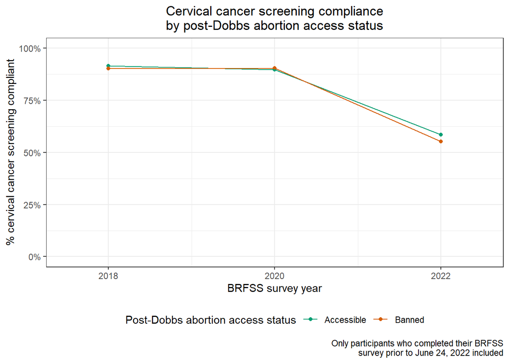

```
## # A tibble: 6 × 3
## # Groups:   postdobbs_cat [2]
##   postdobbs_cat year_brfss mean_ccs_cmplnt
##   <chr>              <dbl>           <dbl>
## 1 Accessible          2018           0.915
## 2 Accessible          2020           0.896
## 3 Accessible          2022           0.585
## 4 Banned              2018           0.903
## 5 Banned              2020           0.905
## 6 Banned              2022           0.552
```

```
## # A tibble: 3 × 2
##   year_brfss mean_ccs_cmplnt
##        <dbl>           <dbl>
## 1       2018           0.913
## 2       2020           0.897
## 3       2022           0.582
```

Below is the test of prior trends. I first run a DID model with the interaction term (aka the DID estimate), and then fit the same model but without the DID estimate interaction term. This allows me to run an ANOVA and get an F-test to quantify if both interaction terms are significantly different than 0 (since my `year_brfss` variable is 2018 vs. 2020 vs 2022)

```
##
## Call:
## glm(formula = ccs_cmplnt_y1n0 ~ factor(postdobbs_cat) + factor(year_brfss) +
##     factor(postdobbs_cat) * factor(year_brfss), family = binomial(link = "logit"),
##     data = brfss_final_ccsdata_predobbs)
##
## Coefficients:
##                                                     Estimate Std. Error z value
## (Intercept)                                         2.373955   0.025086  94.632
## factor(postdobbs_cat)Banned                        -0.138559   0.068011  -2.037
## factor(year_brfss)2020                             -0.217796   0.035143  -6.197
## factor(year_brfss)2022                             -2.029983   0.033954 -59.786
## factor(postdobbs_cat)Banned:factor(year_brfss)2020  0.233230   0.100395   2.323
## factor(postdobbs_cat)Banned:factor(year_brfss)2022  0.002226   0.100640   0.022
##                                                    Pr(>|z|)
## (Intercept)                                         < 2e-16 ***
## factor(postdobbs_cat)Banned                          0.0416 *
## factor(year_brfss)2020                             5.74e-10 ***
## factor(year_brfss)2022                              < 2e-16 ***
## factor(postdobbs_cat)Banned:factor(year_brfss)2020   0.0202 *
## factor(postdobbs_cat)Banned:factor(year_brfss)2022   0.9824
## ---
## Signif. codes:  0 '***' 0.001 '**' 0.01 '*' 0.05 '.' 0.1 ' ' 1
##
## (Dispersion parameter for binomial family taken to be 1)
##
##     Null deviance: 43683  on 52084  degrees of freedom
## Residual deviance: 38832  on 52079  degrees of freedom
## AIC: 38844
##
## Number of Fisher Scoring iterations: 5
```

```
##
## Call:
## glm(formula = ccs_cmplnt_y1n0 ~ factor(postdobbs_cat) + factor(year_brfss),
##     family = binomial(link = "logit"), data = brfss_final_ccsdata_predobbs)
##
## Coefficients:
##                             Estimate Std. Error z value Pr(>|z|)
## (Intercept)                  2.36370    0.02391  98.848  < 2e-16 ***
## factor(postdobbs_cat)Banned -0.06112    0.04122  -1.483    0.138
## factor(year_brfss)2020      -0.18925    0.03290  -5.753 8.76e-09 ***
## factor(year_brfss)2022      -2.02686    0.03193 -63.487  < 2e-16 ***
## ---
## Signif. codes:  0 '***' 0.001 '**' 0.01 '*' 0.05 '.' 0.1 ' ' 1
##
## (Dispersion parameter for binomial family taken to be 1)
##
##     Null deviance: 43683  on 52084  degrees of freedom
## Residual deviance: 38839  on 52081  degrees of freedom
## AIC: 38847
##
## Number of Fisher Scoring iterations: 5
```

|  | Resid. Df | Resid. Dev | Df | Deviance | Pr(>Chi) |
| --- | --- | --- | --- | --- | --- |
| 1 | 52081 | 38839.32 | NA | NA | NA |
| 2 | 52079 | 38832.42 | 2 | 6.899775 | 0.03174921 |

## Placebo test

Here, I am running two placebo tests: one where I ‘pretend’ that Dobbs was implemented in 2019, so 2018 is considered pre-intervention and 2020/2022 are post intervention, and another where I ‘pretend’ that Dobbs was implemented in 2021, so 2018/2020 are pre-intervention and 2022 is post-intervention. This essentialy allows me to see if the something else in time could have contributed to a difference in the outcome prior to the intervention being implemented.

Below is the “pretend the Dobbs decision happened in 2019” test.

```
##
## Call:
## glm(formula = ccs_cmplnt_y1n0 ~ factor(postdobbs_cat) + factor(placebo_2019_pre0post1) +
##     factor(postdobbs_cat) * factor(placebo_2019_pre0post1), family = binomial(link = "logit"),
##     data = brfss_final_ccsdata_predobbs)
##
## Coefficients:
##                                                             Estimate Std. Error
## (Intercept)                                                  2.37395    0.02509
## factor(postdobbs_cat)Banned                                 -0.13856    0.06801
## factor(placebo_2019_pre0post1)1                             -0.98321    0.02956
## factor(postdobbs_cat)Banned:factor(placebo_2019_pre0post1)1  0.23257    0.08332
##                                                             z value Pr(>|z|)
## (Intercept)                                                  94.632  < 2e-16
## factor(postdobbs_cat)Banned                                  -2.037  0.04162
## factor(placebo_2019_pre0post1)1                             -33.260  < 2e-16
## factor(postdobbs_cat)Banned:factor(placebo_2019_pre0post1)1   2.791  0.00525
##
## (Intercept)                                                 ***
## factor(postdobbs_cat)Banned                                 *
## factor(placebo_2019_pre0post1)1                             ***
## factor(postdobbs_cat)Banned:factor(placebo_2019_pre0post1)1 **
## ---
## Signif. codes:  0 '***' 0.001 '**' 0.01 '*' 0.05 '.' 0.1 ' ' 1
##
## (Dispersion parameter for binomial family taken to be 1)
##
##     Null deviance: 43683  on 52084  degrees of freedom
## Residual deviance: 42357  on 52081  degrees of freedom
## AIC: 42365
##
## Number of Fisher Scoring iterations: 5
```

```
## # A tibble: 4 × 7
##   term                 estimate std.error statistic   p.value conf.low conf.high
##   <chr>                   <dbl>     <dbl>     <dbl>     <dbl>    <dbl>     <dbl>
## 1 (Intercept)            10.7      0.0251     94.6  0           10.2      11.3
## 2 factor(postdobbs_ca…    0.871    0.0680     -2.04 4.16e-  2    0.763     0.997
## 3 factor(placebo_2019…    0.374    0.0296    -33.3  1.48e-242    0.353     0.396
## 4 factor(postdobbs_ca…    1.26     0.0833      2.79 5.25e-  3    1.07      1.48
```

And now below is the “pretend the Dobbs decision happened in 2021” test.

```
##
## Call:
## glm(formula = ccs_cmplnt_y1n0 ~ factor(postdobbs_cat) + factor(placebo_2021_pre0post1) +
##     factor(postdobbs_cat) * factor(placebo_2021_pre0post1), family = binomial(link = "logit"),
##     data = brfss_final_ccsdata_predobbs)
##
## Coefficients:
##                                                             Estimate Std. Error
## (Intercept)                                                  2.26779    0.01756
## factor(postdobbs_cat)Banned                                 -0.02539    0.04999
## factor(placebo_2021_pre0post1)1                             -1.92382    0.02884
## factor(postdobbs_cat)Banned:factor(placebo_2021_pre0post1)1 -0.11094    0.08945
##                                                             z value Pr(>|z|)
## (Intercept)                                                 129.148   <2e-16
## factor(postdobbs_cat)Banned                                  -0.508    0.611
## factor(placebo_2021_pre0post1)1                             -66.700   <2e-16
## factor(postdobbs_cat)Banned:factor(placebo_2021_pre0post1)1  -1.240    0.215
##
## (Intercept)                                                 ***
## factor(postdobbs_cat)Banned
## factor(placebo_2021_pre0post1)1                             ***
## factor(postdobbs_cat)Banned:factor(placebo_2021_pre0post1)1
## ---
## Signif. codes:  0 '***' 0.001 '**' 0.01 '*' 0.05 '.' 0.1 ' ' 1
##
## (Dispersion parameter for binomial family taken to be 1)
##
##     Null deviance: 43683  on 52084  degrees of freedom
## Residual deviance: 38871  on 52081  degrees of freedom
## AIC: 38879
##
## Number of Fisher Scoring iterations: 5
```

```
## # A tibble: 4 × 7
##   term                   estimate std.error statistic p.value conf.low conf.high
##   <chr>                     <dbl>     <dbl>     <dbl>   <dbl>    <dbl>     <dbl>
## 1 (Intercept)               9.66     0.0176   129.      0        9.33     10.0
## 2 factor(postdobbs_cat)…    0.975    0.0500    -0.508   0.611    0.885     1.08
## 3 factor(placebo_2021_p…    0.146    0.0288   -66.7     0        0.138     0.155
## 4 factor(postdobbs_cat)…    0.895    0.0895    -1.24    0.215    0.751     1.07
```

## Balancing tests for changes in state-level composition

Here, I am running a set of balancing tests for changes in state/group-level composition. Essentially, the goal is to investigate if there were any age, education level, or urban/rural county changes from 2018 vs. 2020 vs. 2022 comparing states that did and did not ban abortion.

While this test is typically supposed to be performed with pre- and post-intervention data, to see if changes in composition could be the reason for the DID difference, I am looking at pre-Dobbs changes over time to see if there is any evidence at first.

The first test here is the age group test, where the outcome is a binary age variable (30-39 years vs. 40-49 years).

```
##
##             0     1  <NA>
##   30-39 25568     0     0
##   40-49     0 26517     0
##   <NA>      0     0     0
```

```
##
## Call:
## glm(formula = age_cat_collap_young0old1 ~ factor(postdobbs_cat) +
##     factor(year_brfss) + factor(postdobbs_cat) * factor(year_brfss),
##     family = binomial(link = "logit"), data = brfss_final_ccsdata_predobbs)
##
## Coefficients:
##                                                     Estimate Std. Error z value
## (Intercept)                                         0.053171   0.014010   3.795
## factor(postdobbs_cat)Banned                        -0.063635   0.039894  -1.595
## factor(year_brfss)2020                             -0.007086   0.020536  -0.345
## factor(year_brfss)2022                             -0.019105   0.026549  -0.720
## factor(postdobbs_cat)Banned:factor(year_brfss)2020 -0.043480   0.059077  -0.736
## factor(postdobbs_cat)Banned:factor(year_brfss)2022 -0.088795   0.083925  -1.058
##                                                    Pr(>|z|)
## (Intercept)                                        0.000148 ***
## factor(postdobbs_cat)Banned                        0.110690
## factor(year_brfss)2020                             0.730064
## factor(year_brfss)2022                             0.471750
## factor(postdobbs_cat)Banned:factor(year_brfss)2020 0.461730
## factor(postdobbs_cat)Banned:factor(year_brfss)2022 0.290042
## ---
## Signif. codes:  0 '***' 0.001 '**' 0.01 '*' 0.05 '.' 0.1 ' ' 1
##
## (Dispersion parameter for binomial family taken to be 1)
##
##     Null deviance: 72188  on 52084  degrees of freedom
## Residual deviance: 72174  on 52079  degrees of freedom
## AIC: 72186
##
## Number of Fisher Scoring iterations: 3
```

```
##
## Call:
## glm(formula = age_cat_collap_young0old1 ~ factor(postdobbs_cat) +
##     factor(year_brfss), family = binomial(link = "logit"), data = brfss_final_ccsdata_predobbs)
##
## Coefficients:
##                             Estimate Std. Error z value Pr(>|z|)
## (Intercept)                  0.05678    0.01354   4.192 2.76e-05 ***
## factor(postdobbs_cat)Banned -0.09293    0.02733  -3.400 0.000673 ***
## factor(year_brfss)2020      -0.01238    0.01926  -0.643 0.520154
## factor(year_brfss)2022      -0.02827    0.02517  -1.123 0.261364
## ---
## Signif. codes:  0 '***' 0.001 '**' 0.01 '*' 0.05 '.' 0.1 ' ' 1
##
## (Dispersion parameter for binomial family taken to be 1)
##
##     Null deviance: 72188  on 52084  degrees of freedom
## Residual deviance: 72175  on 52081  degrees of freedom
## AIC: 72183
##
## Number of Fisher Scoring iterations: 3
```

|  | Resid. Df | Resid. Dev | Df | Deviance | Pr(>Chi) |
| --- | --- | --- | --- | --- | --- |
| 1 | 52081 | 72175.18 | NA | NA | NA |
| 2 | 52079 | 72173.88 | 2 | 1.29512 | 0.5233212 |

The second test is the education level test, where the outcome is a binary education variable (did not graduate from college or technical school vs. graduated from college or technical school).

```
##
##                                                         0     1  <NA>
##   Did not graduate from college or technical school 25163     0     0
##   Graduated from college or technical school            0 26815     0
##   <NA>                                                  0     0   107
```

```
##
## Call:
## glm(formula = edu_collap_less0more1 ~ factor(postdobbs_cat) +
##     factor(year_brfss) + factor(postdobbs_cat) * factor(year_brfss),
##     family = binomial(link = "logit"), data = brfss_final_ccsdata_predobbs)
##
## Coefficients:
##                                                    Estimate Std. Error z value
## (Intercept)                                         0.07557    0.01403   5.388
## factor(postdobbs_cat)Banned                        -0.44014    0.04051 -10.865
## factor(year_brfss)2020                              0.01176    0.02057   0.572
## factor(year_brfss)2022                              0.19036    0.02675   7.116
## factor(postdobbs_cat)Banned:factor(year_brfss)2020  0.09052    0.05978   1.514
## factor(postdobbs_cat)Banned:factor(year_brfss)2022 -0.07335    0.08463  -0.867
##                                                    Pr(>|z|)
## (Intercept)                                        7.13e-08 ***
## factor(postdobbs_cat)Banned                         < 2e-16 ***
## factor(year_brfss)2020                                0.567
## factor(year_brfss)2022                             1.11e-12 ***
## factor(postdobbs_cat)Banned:factor(year_brfss)2020    0.130
## factor(postdobbs_cat)Banned:factor(year_brfss)2022    0.386
## ---
## Signif. codes:  0 '***' 0.001 '**' 0.01 '*' 0.05 '.' 0.1 ' ' 1
##
## (Dispersion parameter for binomial family taken to be 1)
##
##     Null deviance: 72004  on 51977  degrees of freedom
## Residual deviance: 71710  on 51972  degrees of freedom
##   (107 observations deleted due to missingness)
## AIC: 71722
##
## Number of Fisher Scoring iterations: 3
```

```
##
## Call:
## glm(formula = edu_collap_less0more1 ~ factor(postdobbs_cat) +
##     factor(year_brfss), family = binomial(link = "logit"), data = brfss_final_ccsdata_predobbs)
##
## Coefficients:
##                             Estimate Std. Error z value Pr(>|z|)
## (Intercept)                  0.07251    0.01357   5.344 9.09e-08 ***
## factor(postdobbs_cat)Banned -0.41466    0.02765 -14.995  < 2e-16 ***
## factor(year_brfss)2020       0.02241    0.01932   1.160    0.246
## factor(year_brfss)2022       0.18409    0.02535   7.261 3.84e-13 ***
## ---
## Signif. codes:  0 '***' 0.001 '**' 0.01 '*' 0.05 '.' 0.1 ' ' 1
##
## (Dispersion parameter for binomial family taken to be 1)
##
##     Null deviance: 72004  on 51977  degrees of freedom
## Residual deviance: 71714  on 51974  degrees of freedom
##   (107 observations deleted due to missingness)
## AIC: 71722
##
## Number of Fisher Scoring iterations: 3
```

|  | Resid. Df | Resid. Dev | Df | Deviance | Pr(>Chi) |
| --- | --- | --- | --- | --- | --- |
| 1 | 51974 | 71714.33 | NA | NA | NA |
| 2 | 51972 | 71709.98 | 2 | 4.354337 | 0.1133621 |

The third test is the urban/rural county level test, where the outcome is a binary living in an urban vs. rural county variable.

```
##
##                    0     1  <NA>
##   Urban county 48145     0     0
##   Rural county     0  3937     0
##   <NA>             0     0     3
```

```
##
## Call:
## glm(formula = urban0rural1 ~ factor(postdobbs_cat) + factor(year_brfss) +
##     factor(postdobbs_cat) * factor(year_brfss), family = binomial(link = "logit"),
##     data = brfss_final_ccsdata_predobbs)
##
## Coefficients:
##                                                    Estimate Std. Error z value
## (Intercept)                                        -2.70346    0.02887 -93.638
## factor(postdobbs_cat)Banned                         1.50612    0.05283  28.507
## factor(year_brfss)2020                             -0.15833    0.04399  -3.600
## factor(year_brfss)2022                             -0.23099    0.05904  -3.912
## factor(postdobbs_cat)Banned:factor(year_brfss)2020 -0.04532    0.08079  -0.561
## factor(postdobbs_cat)Banned:factor(year_brfss)2022  0.03895    0.11470   0.340
##                                                    Pr(>|z|)
## (Intercept)                                         < 2e-16 ***
## factor(postdobbs_cat)Banned                         < 2e-16 ***
## factor(year_brfss)2020                             0.000319 ***
## factor(year_brfss)2022                             9.15e-05 ***
## factor(postdobbs_cat)Banned:factor(year_brfss)2020 0.574816
## factor(postdobbs_cat)Banned:factor(year_brfss)2022 0.734176
## ---
## Signif. codes:  0 '***' 0.001 '**' 0.01 '*' 0.05 '.' 0.1 ' ' 1
##
## (Dispersion parameter for binomial family taken to be 1)
##
##     Null deviance: 27902  on 52081  degrees of freedom
## Residual deviance: 26474  on 52076  degrees of freedom
##   (3 observations deleted due to missingness)
## AIC: 26486
##
## Number of Fisher Scoring iterations: 5
```

```
##
## Call:
## glm(formula = urban0rural1 ~ factor(postdobbs_cat) + factor(year_brfss),
##     family = binomial(link = "logit"), data = brfss_final_ccsdata_predobbs)
##
## Coefficients:
##                             Estimate Std. Error  z value Pr(>|z|)
## (Intercept)                 -2.69997    0.02658 -101.590  < 2e-16 ***
## factor(postdobbs_cat)Banned  1.49443    0.03721   40.161  < 2e-16 ***
## factor(year_brfss)2020      -0.17180    0.03691   -4.655 3.25e-06 ***
## factor(year_brfss)2022      -0.22168    0.05055   -4.385 1.16e-05 ***
## ---
## Signif. codes:  0 '***' 0.001 '**' 0.01 '*' 0.05 '.' 0.1 ' ' 1
##
## (Dispersion parameter for binomial family taken to be 1)
##
##     Null deviance: 27902  on 52081  degrees of freedom
## Residual deviance: 26475  on 52078  degrees of freedom
##   (3 observations deleted due to missingness)
## AIC: 26483
##
## Number of Fisher Scoring iterations: 5
```

|  | Resid. Df | Resid. Dev | Df | Deviance | Pr(>Chi) |
| --- | --- | --- | --- | --- | --- |
| 1 | 52078 | 26475.02 | NA | NA | NA |
| 2 | 52076 | 26474.42 | 2 | 0.5986888 | 0.7413041 |